# QuARG - Quality Assurance Report Generator

- *Start* - beginning of date range used in conjunction with the Diagnosis tools; if no time specified, defaults to 00:00:00
- *End* - end of date range used in conjunction with the Diagnosis tools; if no time specified, defaults to 00:00:00
- *Metrics* - comma separated list of metrics, used in conjunction with the `Metrics` and `Metric Plot` buttons to view values for the specified metrics
- *Threshold* - used in conjunction with the `Go To Threshold` button, will pull up all issues that match the provided threshold
- *Network* - networks to be used in conjunction with the Diagnosis tools, as well as `Go To Target`
- *Station* - stations to be used in conjunction with the Diagnosis tools, as well as `Go To Target`; updates automatically as the analyst scrolls through issues station-by-station
- *Location* - locations to be used in conjunction with the Diagnosis tools, as well as `Go To Target`
- *Channel* - channels to be used in conjunction with the Diagnosis tools, as well as `Go To Target`

For each of the target fields above (`Network`, `Station`, `Location`, and `Channel`), wildcards or comma-separated lists are accepted. Required fields are dependent on the web service being used. For example, `Noise Modes` calls on the Noise Mode Timeseries webservice, which requires a single target to be specified without wildcarding. In those cases where the analyst is interested in a target with an empty location code (’‘), they should try using’–’ instead.

**Navigation**

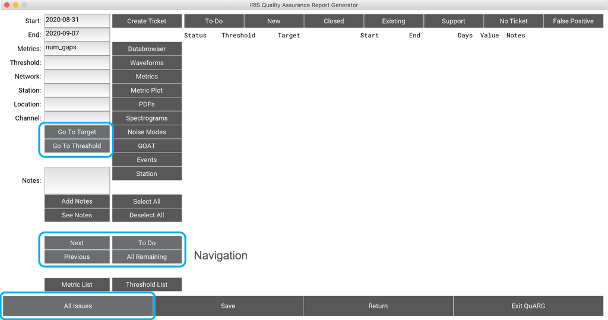

The navigation buttons allow the user to pull up issues in different ways.

`Next` and `Previous` will move through the issues station-by-station in alphabetical order.

`To Do` and `All Remaining` are ways to look at issues based on their Status. `To Do` will only display those issues that are still marked as TODO as the user navigates through them using the `Next` and `Previous` buttons. `All Remaining` will pull up one large list of all issues that are still marked as TODO.

`Go To Target` and `Go To Threshold` will take the inputs provided in the Inputs Pane and use those to pull up all matching issues. For `Go To Target`, it will use any information provided in the `Network`, `Station`, `Location`, and `Channel` fields, wildcarding any that are left blank (ignoring the threshold information). `Go To Threshold` will look for any thresholds matching that provided in the `Threshold` input field and pull up all that match (ignoring the target information).

`All Issues` will pull up a list of every issue, all in one view.

**Notes and Status**

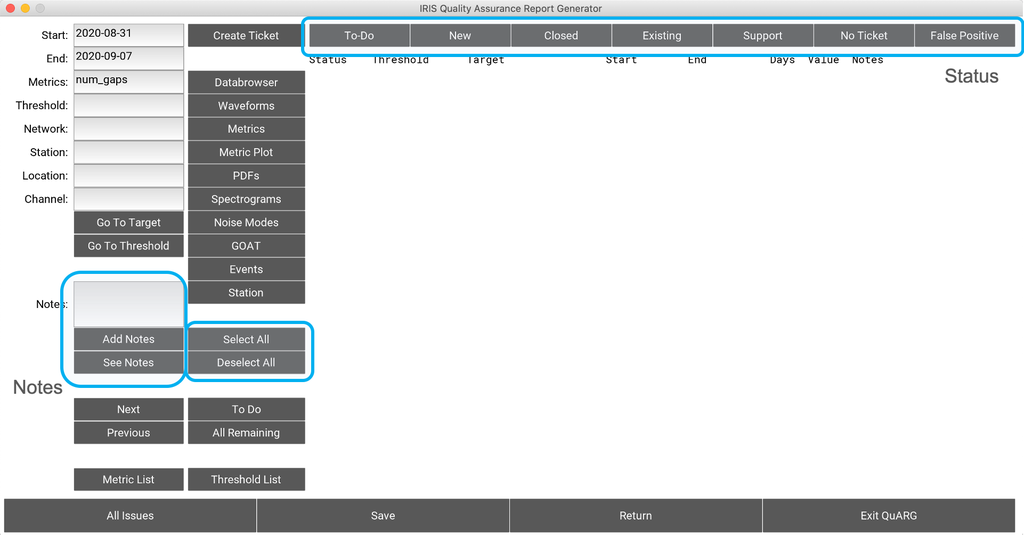

As described earlier, there are two fields from the `Issue Pane` that can be altered to help the analyst keep notes as they process through the issue list. These fields are `Status` and `Notes`.

Each row in the `Issue Pane` is selectable, and multiple can be selected at once. By using the `Select All` or `Deselect All` buttons, you can either select all of the issues displayed on the screen, or deselect any that may have been selected. To change the status or notes of a line, first ensure that it is selected. Then:

- **Notes** To add notes, write any notes in the `Notes` text box and click the `Add Notes` button. The notes will be immediately update for the selected lines. Be aware that the `Issue Pane` will truncate the text for display only - the full text is still available. To see the full text, use the `See Notes` button, and it will display a popup with the notes of any selected lines.
- **Status** There are a set number of status options, which roughly align with those available in the Ticketing System. Along the top there are seven possible statuses - the exact meaning can depend on the analysts use, but they are generally self-descriptive:

| Status | Description |
| --- | --- |
| `To-Do` | Marks the status as “TODO”, which is the default status. |
| `New` | For issues that have a new ticket created |
| `Closed` | For issues that have tickets that are now closed out because the issue has been fixed |
| `Existing` | For issues that have tickets that already exist and the issue persists |
| `Support` | For those issues that are good to note but might not actually be a problem or shouldn’t be included in a report and therefore have a support ticket in the Ticketing System - we often have use this for… |
| `No Ticket` | For things that might be real signals but are not worth a ticket |
| `False Positive` | For times when the thresholds triggered when there was truly nothing wrong - this is useful for figuring out what thresholds might benefit from definition changes. To change a status, simply click on … |

**IMPORTANT NOTE:** It is VERY important to note that any changes that you make here, whether adding notes or changing a status, is NOT immediately saved. To save your work, hit the `Save` button at the bottom of the screen. We suggest doing this often so that work is not lost if you accidentally close out of the program.

**Diagnosis Tools**

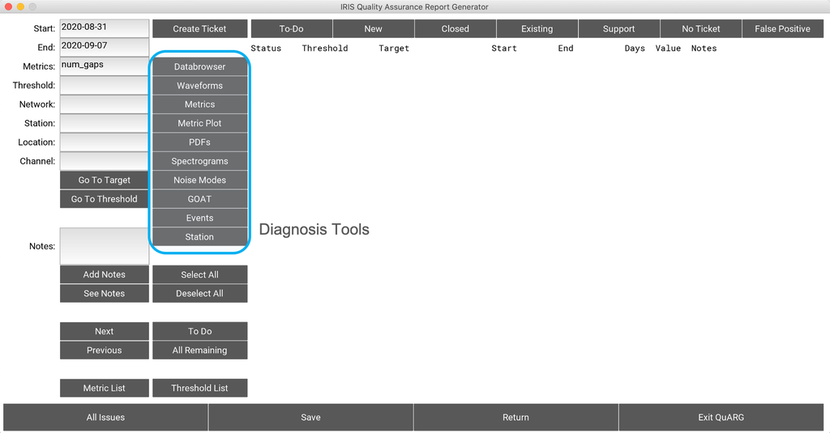

The diagnosis tools are a series of links to various web services that have proven useful in identifying and diagnosing the potential issues. Except for `Databrowser`, they all take input form the Inputs section described above.

| Tool | Description |
| --- | --- |
| [Databrowser](http://ds.iris.edu/mustang/databrowser/) | Databrowser is a tool that allows users to plot MUSTANG metrics. These include Metric Timeseries (plotting metric values over time), Gap Duration plots, Network and Station boxplots, as well as some o… |
| [Waveforms](https://service.earthscope.org/irisws/timeseriesplot/1/) | This button will retreive and display waveform data from the EarthScope timeseriesplot service. This requires all target fields to be specified, though it can accomodate a comma-separated list. Users … |
| [Metrics](https://service.earthscope.org/mustang/measurements/1/) | The `Metrics` button opens a web browser page that displays metric values from the MUSTANG Measurements web service. It uses input from all of the input fields except for `Threshold`. `Start` and `End… |
| Metric Plot | The `Metric Plot` button uses the same inputs as the `Metrics` button, but rather than opening a web page with tabular data, it generates a simple timeseries plot of the requested values. |
| [PDFs](https://service.earthscope.org/mustang/noise-pdf-browser/1/) | Opens a webpage with monthly PDFs for the requested targets, beginning with the month of `Start`. |
| [Spectrograms](https://service.earthscope.org/mustang/noise-pdf-browser/1/) | Opens a webpage with the spectorams for the requested targets, for the time span of `Start` to `End`. If no dates are provided, will do for the entire span of the targets (from the beginning of the ea… |
| [Noise Modes](https://service.earthscope.org/mustang/noise-mode-timeseries/1/) | Opens a webpage to the Noise Mode Timeseries plot. All `Network`, `Station`, `Location`, and `Channel` fields must be filled, with only one target allowed (ie, no wildcarding or lists). Will use the `… |
| [GOAT](http://ds.iris.edu/ds/newsletter/vol2/no1/217/gapoverlap-analysis-tool-goat/) | GOAT is a fairly simple tool that displays data continuity and gaps visually. This button will open a webpage that displays the plot for the target and dates specified. All target fields must be fille… |
| [Events](https://earthquake.usgs.gov/fdsnws/event/1/) | Opens a webpage of the USGS event service based on the `Start` and `End` dates specified. It will list all earthquakes M5.5 and larger, as MUSTANG event-based metrics do not calculate on smaller event… |
| [Station](https://service.earthscope.org/fdsnws/station/1/) | Opens a channel-level web page of the EarthScope Station service, using provided target information. Any blank field will be wildcarded, and lists and wildcards are allowed; start and end times are ig… |

**Metrics and Thresholds**

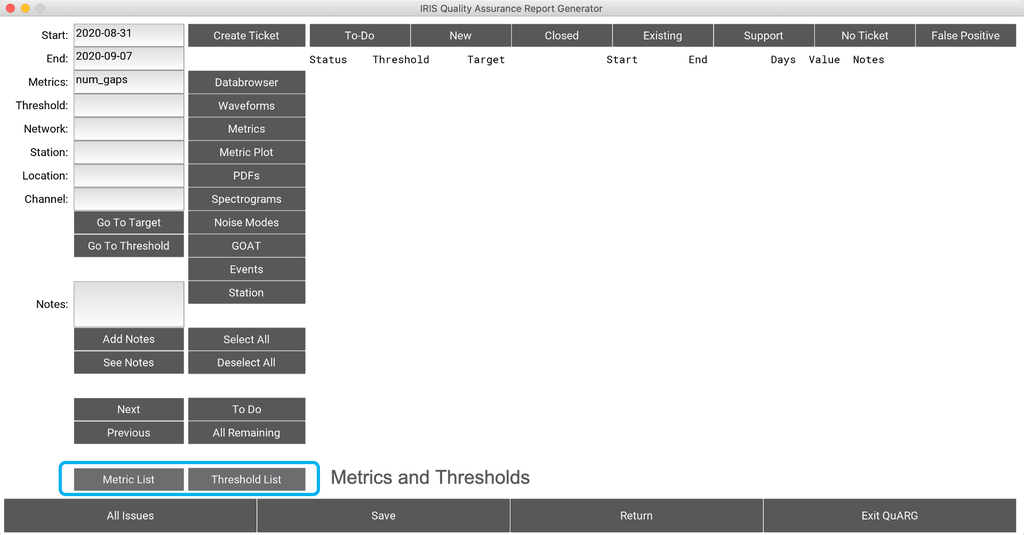

To help make it easier to a) remember what the definitions are for any given threshold, b) see what metrics are in which thresholds, and c) see a list of all possible metrics for your reference, there are a couple of buttons near the bottom that will provide this information.

`Metric List` produces a popup that lists all of the metrics available from the MUSTANG web services. Unlike many things in QuARG, this list has fields that can be selected (via double click or click-and-drag of the cursor), copied, and pasted. That way you can copy a metric from the list and then paste it into the `Metrics` field in the Inputs section above.

`Threshold List` produces a popup of all defined thresholds so that you can easily see what metrics and cutoff values were used for any given threshold. This list also has the ability for copy and paste, so again you can select (double click) a metric from the theshold, then copy and paste it into the `Metrics` field of the Inputs section above.

**Create Ticket**

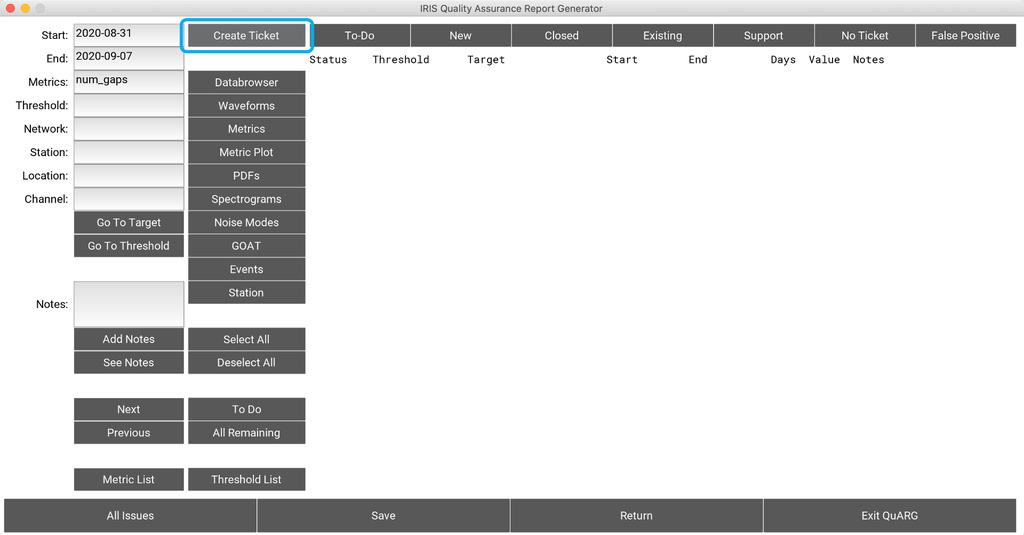

Described in much greater detail below, the `Create Ticket` button will open a new screen where an actual ticket can be created. Remember, only *tickets* are used in the final report, so no matter what other notes and status changes you make as described above, what truly matters are what tickets are created/edited/closed.

**Save**

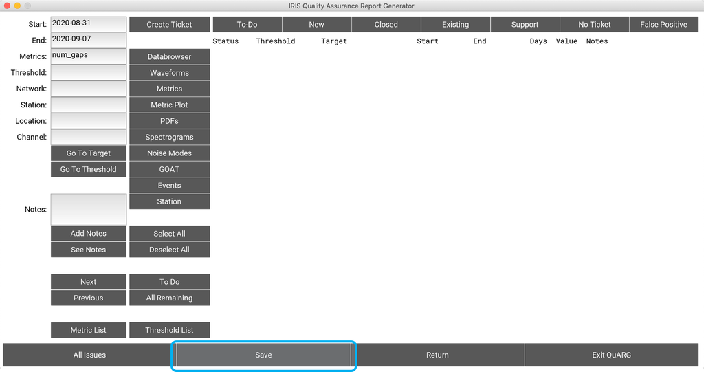

To save your progress, hit the `Save` button. It is recommended to do this frequently so that work is not lost in case the program closes unexpectedly. When the `Save` button is hit, the `Issue File` (see Output Files) is updated to reflect the current state.

### Create Ticket Form

Back to Table of Contents

#### About Tickets

Tickets are the backbone of the final report. You will be able to filter which tickets are included in the report, but any information - all descriptions, links, dates, images, etc - in the in the final report come directly from the tickets themselves. This means that you should provide as much information in the ticket as you want in the report. Depending on your particular use, it is worth thinking of these tickets as a way to convey the scope of the problem to the field crew so that they can adequately plan a way to fix the problem. What is the problem? (to the extent that you can determine), when did it begin?, what station and channels are affected?, what figures could be useful to explain the issue?. Then on top of that there is information that helps you, as the analyst, to track issues as they arise and are resolved and to track which thresholds and metrics are finding issues (this could be useful in tweaking threshold definitions, potentially).

Any real issue should have a ticket created for it. We have found that many networks want to know about and track issues that came and went within a reporting period, so as to have a complete picture of the network. If that is the case, then you may be creating Closed or Resolved tickets for those issues, in addition to creating New tickets for those issues that are still a problem. And of course, as the issue described in a New ticket is dealt with, you will want to transition it to In Progress, Resolved, or Closed. You are free to determine the exact use of the status options for your network, it’s just a good idea to be consistent.

This is a suggestion: At the beginning of every report, go through the open tickets to see if they are still problems. If so, you can leave that ticket open and mark the issue (in the `Issue Pane`) as Existing. If it is no longer a problem, then close the ticket out with all of the updated information about it (such as an End Date). That way, while examining issues, you don’t have to wade through issues that you already know about and are ticketed. As of right now, it is not possible to have both the list of tickets and list of current issues open at once. As a way around this it may be worth opening two instances of QuARG and using one to look at and edit tickets, and the other to look at and mark issues. This is non-ideal, but is easier than flipping between the two within one application.

#### Creating a Ticket

There are two ways to enter the Create Ticket window. One way is as listed above - through the Examine Issues window by clicking the `Create Ticket` button at the top. The other way is through the `Create Ticket` button in the `View Tickets Tab`.

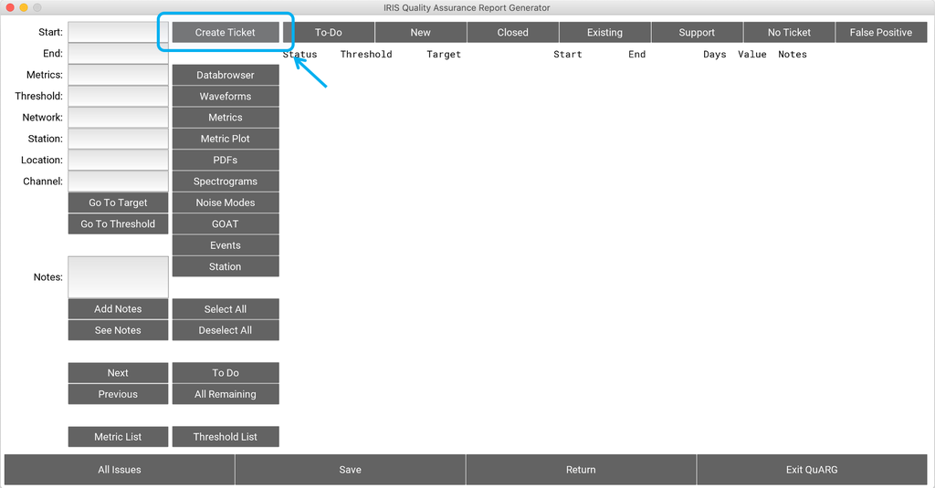

OR

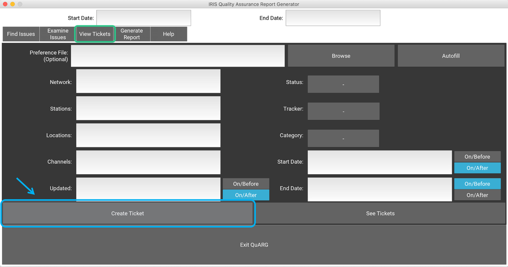

Regardless of how you get there, you will be taken to the same place, where you will fill in a bunch of information and then *submit* the ticket:

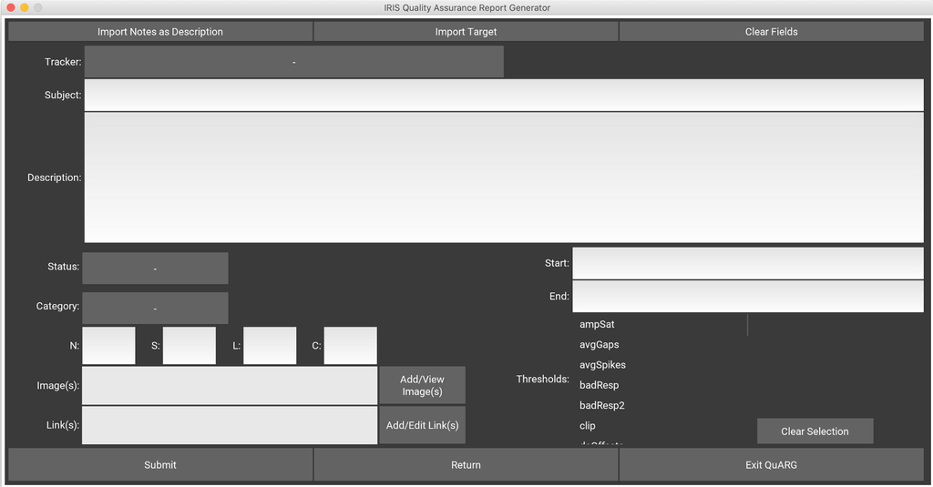

There are 14 fields that can be filled in, with some being required and others optional.

**Required Fields**

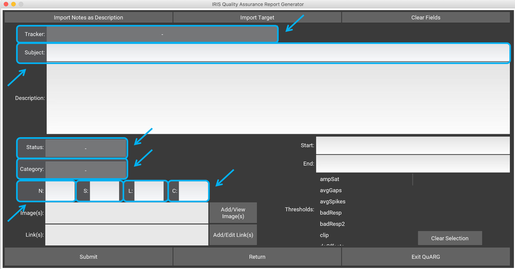

These are the *Required* fields, and are the core pieces of information needed to track an issue in QuARG:

| field |  | Description |
| --- | --- | --- |
| *Tracker* | required | Dropdown menu with two options: `Data Problems` or `Support`. Most tickets will likely belong in `Data Problems`, but `Support` is useful for recurring or persistent signals that trigger certain thres… |
| *Subject* | required | Text input. A short description of the issue, such as “Data Outage” or “Masses off Center” for example. |
| *Status* | required | Dropdown menu with the following options to indicate the status of the issue/ticket: `New`, `In Progress`, `Resolved`, `Closed`, `Rejected` |
| *Category* | required | Dropdown menu with the following options to indicate the general category of the issue: `Amplitudes`, `Completeness`, `Metadata`, `Other`, `Timing` |
| *N* | required | Text input. The network(s) affected by the issue described in the ticket. Can be wildcarded or a comma-separated list, and the use of square brackets (eg, A[KV]) is acceptable, but beware that when do… |
| *S* | required | Text input. The station(s) affected by the issue described in the ticket. Can be wildcarded or a comma-separated list, and the use of square brackets (eg, IM0[1234]) is acceptable, but beware that whe… |
| *L* | required | Text input. The location(s) affected by the issue described in the ticket. **Note**, if there is no location code (“blank” code) then you should instead use “–”. Leaving the field blank will prevent t… |
| *C* | required | Text input. The channel(s) affected by the issue described in the ticket. Can be wildcarded or a comma-separated list, and the use of square brackets (eg, BH[12Z]) is acceptable, but beware that when … |

**Optional Fields**

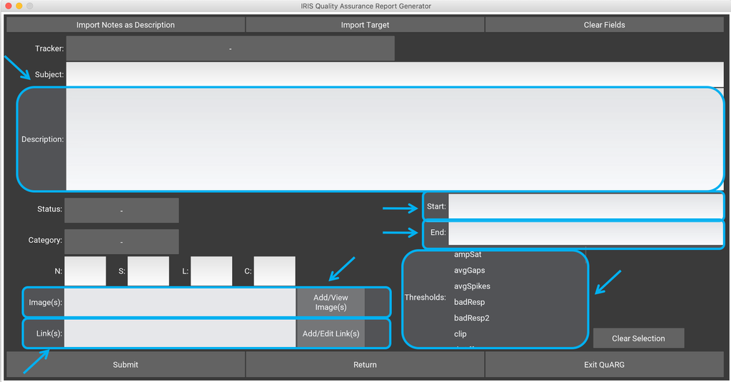

Then there are the optional fields, which supplement the required fields. In most cases, these fields will be filled with information, but it’s not always necessary that they are:

| field |  | Description |
| --- | --- | --- |
| *Description* |  | Text input. A more detailed description of the issue. |
| *Image(s)* |  | This will display an attached images, but to add or remove images then use the `Add/View Image(s)` button (see below). If provided, the image will be copied locally and included in the report. |
| *Link(s)* |  | This will display any supplied links, but to add or remove links then use the `Add/Edit Link(s)` button (see below). If there is a link that ought to be included in the htlm report, it can be added he… |
| *Start* |  | Text input. Date that the issue began, formatted as YYYY-mm-dd. If unknown, it can be left blank. |
| *End* |  | Text input. Date that the issue ended or was resolved, formatted as YYYY-mm-dd. If unknown, or still in progress, can be left blank. |
| *Thresholds* |  | Selectable list. The thresholds that were flagged and led to the discovery of the issue. Multiple thresholds can be selected. |

*Add/View Image(s)*

To add or remove images, add captions, or view images, you use the `Add/View Image(s)` button. This will supply a popup that looks like this:

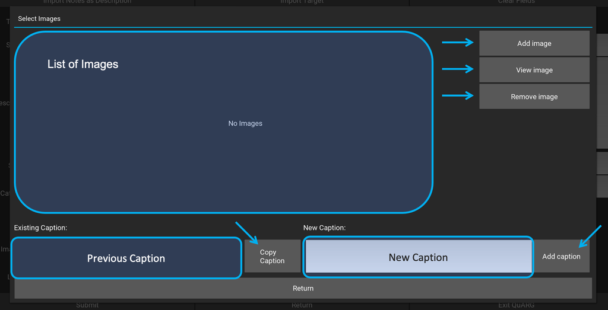

- List of Images - this section will be filled with a selectable list of any images that have been attached. When an image is selected, it will turn blue and the caption (if there is one) will be displayed in the `Existing Caption` section (below left)
- Add Image button - use this to navigate to the image file. When selected, it will be added to the List of Images and to the ticket
- View Image button - this will open the file selected in the List of Images to view
- Remove Image button - removes the selected file from the List of Images and from the ticket
- Existing Caption display - when an image is selected from the list above, the caption will be displayed here (if there is one)
- Copy Caption button - take the displayed caption (to the left) and copies the text into the editable `New Caption` input box (to the right) so that you can easily edit existing captions
- New Caption input - this is where you can type out a caption for an image
- Add Caption button - adds the text in the `New Caption` input to selected image from the List of Images

When an image is added here, it will be reflected in the `Images(s)` field in the Create Ticket Form.

*Add/Edit Links(s)*

To add or remove links, use the `Add/Edit Link(s)` button. This generates a popup:

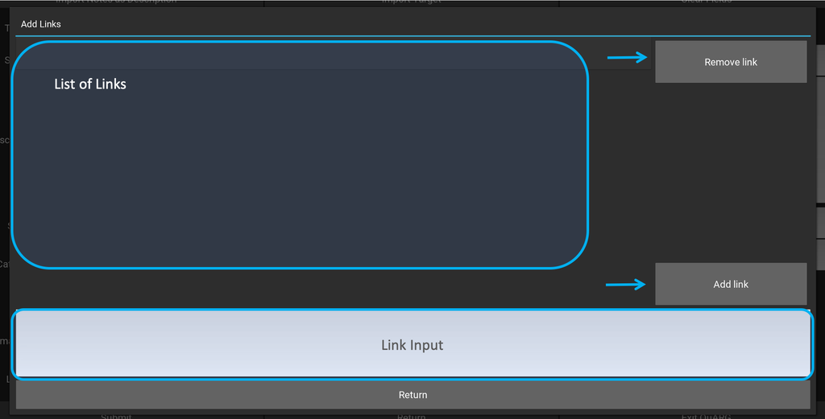

- List of Links - this section will have a selectable list of any links that have been attached. When a link it added, it will show up here.
- Link Input - where you can type (or copy/paste) the link you want to add to the ticket
- Remove Link button - will remove any selected Links from the List of Links
- Add Link button - adds the link supplied in the Link Input section, and to the ticket.

When a link is added here, it will be reflected in the `Link(s)` field in the Create Ticket Form.

**Other Buttons** In addition to those fields, there are other auxiliary buttons to help create the ticket.

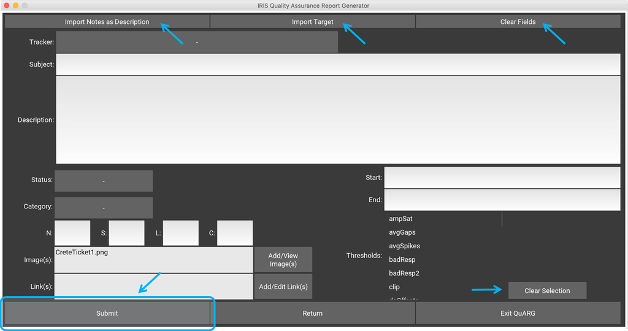

- `Import Notes as Description` - If a line is selected in the Examine Issues window, this will take the `Notes` field and import that into the *Description* field of the ticket. When multiple lines are selected, it will import the description if all `Notes` match. If there are multiple values in `Notes`, then it will spit out a message to the command line indicating this and will not import the *Description*.
- `Import Target` - If a line is selected in the Examine Issues window, this will take the `Target` field and import that into the *Target* field of the ticket. When multiple lines are selected, it will combine the targets into the most concise target it is able to.
- `Clear Fields` - Clears all fields in the ticketing form.
- `Clear Selection` - Clears all selections from the `Thresholds` list.
- **`Submit`** - Submits the ticket to the SQLite database. To edit or remove an existing ticket, you will need to use the `See Tickets` button in the View Tickets tab, described below.

To add a ticket, you need to hit **Submit** - this will add it to the SQLite ticketing database and clear all fields, prepping it for the next ticket.

To update a ticket, you use a very similar but slightly different `Update Ticket Form`

To see a list of all tickets that exist in the ticketing system, or some subset of tickets, use the `View Tickets Tab`

## View Tickets Tab

Back to Table of Contents

The View Tickets tab is the way that you can interact with tickets that already exist within the ticketing system (SQLite database table). The fields within this tab are used to create a SQL query to retrieve tickets that match the provided criteria, and any matching tickets are displayed in a popup when the `See Tickets` button is pushed. No fields are required here, and if everything is left blank then all tickets will be retrieved.

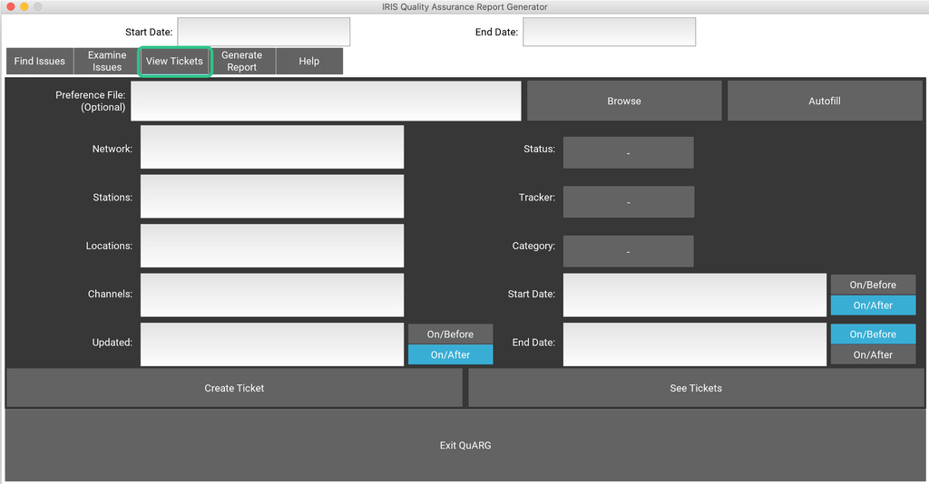

At the top is the same `Preference File` field that exists on all other tabs, but it is optional here. If the preference file has already been loaded within another tab, it will also be displayed here. The `Browse` and `Autofill` buttons do the same as in other tabs as well - `Browse` will popup a file listing where you can navigate to and select the preference file. `Autofill` will take values from the preference file and fill in the target-related fields (`Network`, `Stations`, `Locations`, and `Channels`).

- Network - Network(s) to retreive, comma-separated list with wildcards permitted. Square brackets ([]) can also be understood.
- Stations - Stations(s) to retreive, comma-separated list with wildcards permitted. Square brackets ([]) can also be understood.
- Locations - Location(s) to retreive, comma-separated list with wildcards permitted. Square brackets ([]) can also be understood.
- Channels - Channel(s) to retreive, comma-separated list with wildcards permitted. Square brackets ([]) can also be understood.
- Updated - Date that ticket was last updated; YYYY-mm-dd.
  - On/Before - find tickets that have an updated date on or prior to the `Updated` date
  - On/After - find tickets that have an updated date on or after to the `Updated` date
- Status - Status of tickets to be retrieved. If all statuses are desired, then select “Select All” (“-”).
- Tracker - Tracker of tickets to be retrieved. If all trackers are desired, then select “Select All” (“-”).
- Category - Category of the tickets to be retrieved. If all categores are desired, then select “Select All” (“-”).
- Start Date - Start date associated with the tickets to retrieve; YYYY-mm-dd
  - On/Before - find tickets that have a start date on or prior to the `Start Date` date
  - On/After - find tickets that have a start date on or after the `Start Date` date
- End Date - End date associated with the tickets to retrieve; YYYY-mm-dd
  - On/Before - find tickets that have an end date on or prior to the `End Date` date
  - On/After - find tickets that have an end date on or after the `End Date` date

Each pairing of On/Before and On/After buttons are associated with the field directly to their left and the selected button will display as blue. If all time spans (before and after) are desired, then leave the date field empty.

Near the bottom, there are two buttons: `Create Ticket` and `See Tickets`. `Create Tickets` leads you to the form to generate a new ticket, as described above. `See Tickets` will use all provided inputs and find any matching tickets, which it will then display in a popup. Any line in that popup can be clicked on to view the ticket in more detail.

**Tip**: If `See Tickets` isn’t displaying tickets that you know are in the system, then try loosening the query requirements. Removing target constraints, especially on the channel level, may be able to retrieve the ticket(s) you are looking for. QuARG has some fairly strict requirements for the target fields, so while it is able to understand a considerable range of notations (*, ?, [], comma), if either the ticket or the query have characters outside of QuARG’s capabilities, then it may not be able to retrieve those tickets easily.

### Ticket List

Back to Table of Contents

Selecting the `See Tickets` button will display a list of all tickets that match the criteria you provided. In the list, each line is selectable and if selected will take you to another window where you can view the ticket in more detail.

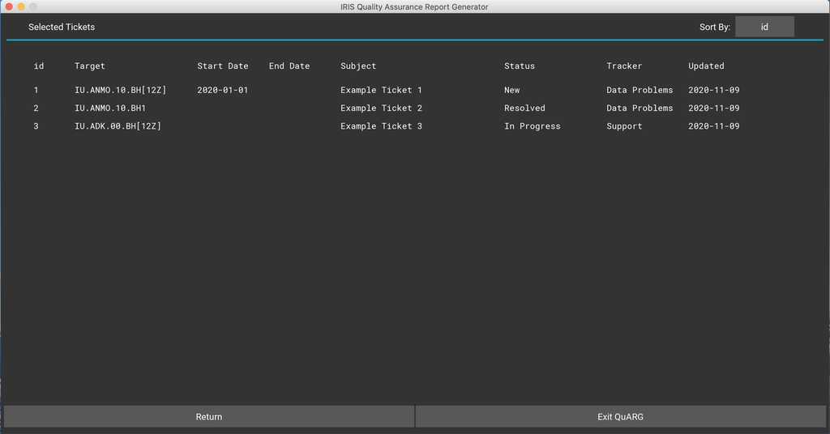

This list was generated using the following fields (all others left as blank or “See All”): `Network`=IU, `Channels`=BH*.

This screen displays the following: id (the id number of the ticket within the database table), Target, Start Date, End Date, Subject, Status, Tracker, and Updated date.

In the top right corner, there is a dropdown menu that allows you to sort the ticket by a number of different fields. By default tickets will sort by id, but selecting any of the other categories will immediately sort the tickets by that field. Once the sorting has been set, it will continue to be sort in that way until you either choose another sorting option, or close QuARG.

By clicking on any line, it will take you to another page to view the ticket in more detail:

### Update Tickets Form

Back to Table of Contents

When you initially click on the ticket, it’ll open the Update Ticket form with all fields from the ticket loaded up. Below, I have used “Example Ticket 1” from the ticket list above:

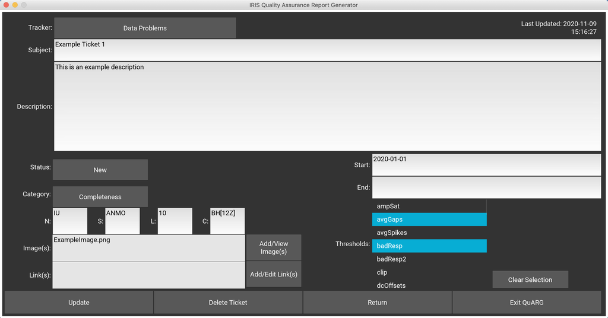

In this case, fields that have information are the Tracker, Subject, Description, Status, Category, and Target Fields (N,S,L,C), Image(s), Start, and Thresholds. All others were left blank when the ticket was initially created or last updated.

The fields in this form can be edited just like when creating a ticket. If you make changes to the ticket, you can save those changes by clicking on the `Update` button in the bottom left. This will update the ticket in the database to reflect any you changes you made. For example, if the issue is resolved you will want to update the Status from New to Resolved. You may also want to add an End date that reflects when the station returned to normal.

NOTE: As the ticket is updated (the `Update` button is pressed) the “Last Updated” datetime displayed at the top will change to reflect the time when that ticket was updated and a popup will let you know that it was able to save successfully.

Alternatively, you can delete the ticket by using the `Delete Ticket` button. We suggest keeping tickets after an issue is resolved, but there are times when deleting a ticket makes sense. For example, if a ticket is accidentally generated or multiple tickets exist for the exact same issue.

## Generate Report Tab

Back to Table of Contents

Once all issues have been ticketed, and any old tickets have been closed or resolved, it is time to generate the report. The bulk of the report, the most important part of it, is derived directly from the tickets that are selected to be included. So it is important to make sure that your tickets include the type and volume of information that you want for your report.

Because you can use either the QuARG ticketing system or your favorite external ticketing system, the prgram utilizes a text file that translates between the tickets and the final report. This way, you can either use the internal tickets and QuARG will take care of generating this file, or you can produce the file manually and supply it to QuARG to generate the final report. The path to this file (whether created internally or externally) is a required input for creating a report, since it needs to know where to load the text file from.

All of this is done using the Generate Report tab:

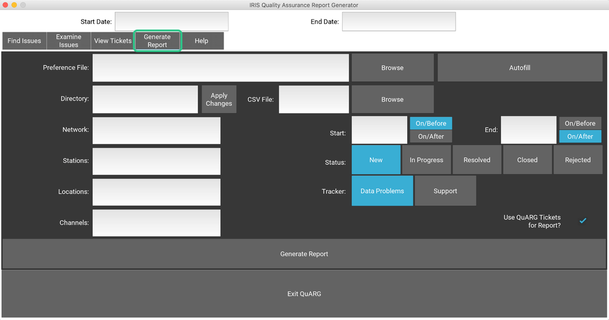

Much like the View Tickets Tab, this one has fields that help to subset the tickets that the program will retrieve and use in the Report. While every field *except for* `Preference File`, `Directory` *and* `CSV File` are technically optional, if you do not provide some constraints then the report will include all issues, past and present, indiscriminately. So, at a very minimum, it is a good idea to subset based on the `Start` and `End` dates.

The following fields are available to edit:

#### Required

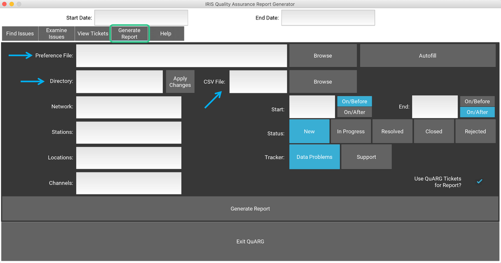

- *Preference File*:  
  This contains a number of fields used while generating the report. Either type in the location of the file, or Browse to it. Autofill will provide the `Directory` and `CSV Files` from the Preference File.
- *Directory*:  
  The directory to write (if applicable) and read the intermediary file. This is also the directory where the final report will be written.
- *CSV File*:  
  The filename of intermediary file, described in more detail here. The details of the file are only necessary if you will be creating the file from an external ticketing system… if using QuARG for ticketing, then it will create and read from this file without input from you.

#### Optional, but suggested

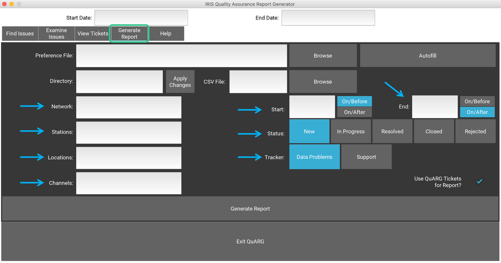

Available fields for subsetting include the usuals:

- Targets:  
  Any of these target fields will be wildcarded if left blank. All can ingest a comma-separated list, with wildcards allowed.
  - *Network*
  - *Stations*
  - *Locations*
  - *Channels*
- Dates:  
  If these fields are left blank, it will match to all start and/or end dates. If a ticket does not have a start and/or end, then it will match to any Start/End dates provided.
  - *Start*, with associated `On/Before` and `On/After` buttons; format YYYY-mm-dd
  - *End*, with associated `On/Before` and `On/After` buttons; format YYYY-mm-dd
- *Status:*  
  Select all statuses that should be included in the report
- *Tracker:*  
  Select which Trackers should be included the report. Since “Supoort” tickets are generally for internal use and not included in reports, it is likely that you will keep this as just “Data Problems” but ultimately it is up to you and how you use the two trackers.

If you are interested only in issues that still persist at the time that the report is generated, then you can select `New` and `In Progress` (depending on what you use in your tickets) and leave the `Start` and `End` fields blank.

If you are interested in *any and all* issues that were active during the reporting period, then you can select all `Status` options and have an `End` (`On/After`) of the first day of the report period. Since a blank End in a ticket will match to any End query here, this will pull up all cases where there is either no end time for the ticket or it ended sometime during the reporting period, regardless of when it started.

#### Generate the Final Report

At the bottom right, you’ll notice a checkbox indicating whether you used the internal ticketing system or if you used your own external system. This is important because that tells the program whether it should look for tickets in the local SQLite database or not. If this box is checked, then the program will generate the `Ticket File` as described in the Output Files section.

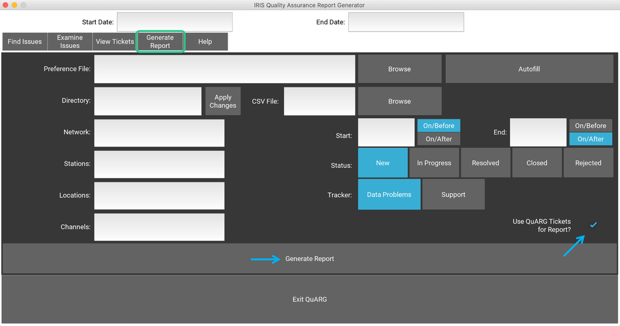

##### If the box is checked

Then you do not have to do anything special - when you hit the `Generate Report` button, QuARG will query the database using the Optional fields above and write out to the `Directory`/`CSV Filename`, then immediately use that file to generate the final report.

If either file already exists - either the intermediary csv file or the final report - when you `Generate Report`, QuARG will ask you if you want to rewrite that file. If both files already exist, then it will ask you twice: once for the csv file, then for the final report.

##### If the box is not checked

Then you must supply the file at `Directory`/`CSV Filename` yourself. See `Ticket File` to learn more about the format and fields required if using an external system. When you hit `Generate Report`, QuARG will look for this file and then generate the final report from it.

If the final report already exists when you `Generate Report`, it will ask if you want to rewrite it.

##### Final Directory

In the end, the report will exist in the `Directory` alongside the issue and ticket files. If there are images in the included tickets, they will be copied locally and the report and all images will live in a directory together, along with a zipped version of that directory for easier sharing. This means that, in the end, the directory will either contain:

| *No Images* | *Images Included* |
| --- | --- |
| Issue File | Issue File |
| Ticket File | Ticket File |
| Final Report | Subdirectory with - local copy of all images - the final report |
|  | Zipped version of the subdirectory |

## Output files

Back to Table of Contents

Over the course of the full QA process (Find issues, Examine issues, Ticket issues, and Generate Report) there a few files that will be generated. For the most part, the user does not need to be overly aware of the intermediate files, but it is important to have an understanding of the purpose of each file.

##### Issue File

Back to Table of Contents

This is the file that contains a list of all potential issues discovered by using the MUSTANG metrics and thresholds. The precise name and location of the file is determined by either the `Directory` and `Issue File` fields. Remember that any value input into the program will override the values in the Preference File.

The contents of this file is intended to be read into the the Examine Issues tool of QuARG. As such, it is not the most human-readable though it is certainly possible to decipher the contents of the file. Each field is separated by a pipe ‘|’, with the following fields:

| field | Description |
| --- | --- |
| *threshold* | The threshold that was triggered for this particular target for these days |
| *target* | Affected target |
| *start day* | First of consecutive affected days - any consecutive days are grouped together into a single line |
| *end day* | Final of affected days - any consecutive days are grouped together into a single line |
| *number of days* | Number of consecutive affected days |
| *value* | the value of any average or median thresholds |
| *status* | Status of issue - this begins as “TODO” and will change as the status is updated using the Examine Issues tool |
| *notes* | Any notes you want to leave for yourself about the issue to help keep track of what you know |

As the analyst works through the issues using the Examine Issues tool, any updates will be recorded in this file. That means that this file is where the analyst truly keeps track of the progress they make as they go through the issue list. Be careful to not accidentally delete this file, as all progress will then be lost.

In addition there is a backup copy of the issue file. This file has the same name as the original file, but with an additional .bck extension: `backup_copy = output_file + '.bck'`

##### Ticket File

Back to Table of Contents

After all issues have been examined and real issues ticketed, as well as existing tickets updated to reflect any potential changes since the previous report, there is an intermediate file that bridges the gap between the tickets and the final report. If the analyst is using the built in ticketing system, which is the most likely case, the file is generated using the *Generate Report* button in the Generate Report tab.

The file is a comma separated value file that includes information that will be put into the report. At the top is a header with the fields. Much like the Issue File, it is not meant to be used by humans directly but instead read back into QuARG as an input to the Generate Report script (using the *Generate Report* button in the Generate Report tab).

The file includes the following fields:

| field | Description |
| --- | --- |
| *ID* | Ticket ID number |
| *Tracker* | Which tracker the ticket was assigned to |
| *Target* | Target(s) covered by that ticket |
| *Start Date* | Start date of identified issue. May be left blank if unknown |
| *Category* | The general category that the issue falls under. For example: Amplitudes, Completeness, Metadata, Timing, Other |
| *Subject* | A few word description of the problem |
| *Thresholds* | Thresholds used to discover the issue |
| *Images* | Path to the image, if included |
| *Image Captions* | Caption for the image, if included |
| *Links* | URLS to be included as links in the report |
| *Status* | Status of ticket. If using internal ticketing systen, statuses include: New, In Progress, Resolved, Closed, Rejected |
| *End Date* | Date that issue was resolved, if applicable |
| *Description* | A detailed description of the issue |

In the case where the analyst would prefer to use an external ticketing system, QuARG is able to absorb the ticket information through the use of this CSV file. This file is ingested and converted into the final HTML Report, but to do so it must be of a very specific format. If using the internal ticketing system, then you do not need to know the details of this file.

At the very top of the file is the following header:

```
id,tracker,target,start_date,category,subject,thresholds,images,caption,links,status,end_date,description
```

The lines that come after that follow that pattern, with quotation marks (‘"’) around any fields that may have a comma in them. For example:

```
id,tracker,target,start_date,category,subject,thresholds,images,caption,links,status,end_date,description
4,Support,UU BEI 01 EHZ,2019-12-01,Other,Example Ticket,"gapsRatioGt12, glitch",/Users/laura/QA_reports/testImage.jpg,"This is a figure caption, with a comma so it has quotation marks",https://service.earthscope.org/mustang/measurements/1/query?metric=percent_availability&net=YO&cha=?XH&format=text&…
```

The most important thing is that the ticketing system used either has these fields, or has an equivalent, and that the tickets can be exported into a csv file of this format. Any missing fields can be left blank if necessary. For example, using a Redmine ticketing system, we are able to use the ‘Export to CSV’ function and choose what columns are exported. It may take an intermediate step to convert the CSV into the correct format, in which case it is probably worth setting up a workflow to do the conversion for you. Depending on the complexity, it *might* be worth delving into the code to change the required format - just be wary of doing that: it may create unintended consequences.

##### Final Report

Back to Table of Contents

The HTML Report is the final file to come out of the process - it is the file that condenses all of the information that the analyst learned about the issues while sifting through them into a single, easy to navigate report. The report format is an .html file that will open in a browser, with a filename along the lines of `NETWORK_Netops_Report_YYYYmm.html`.

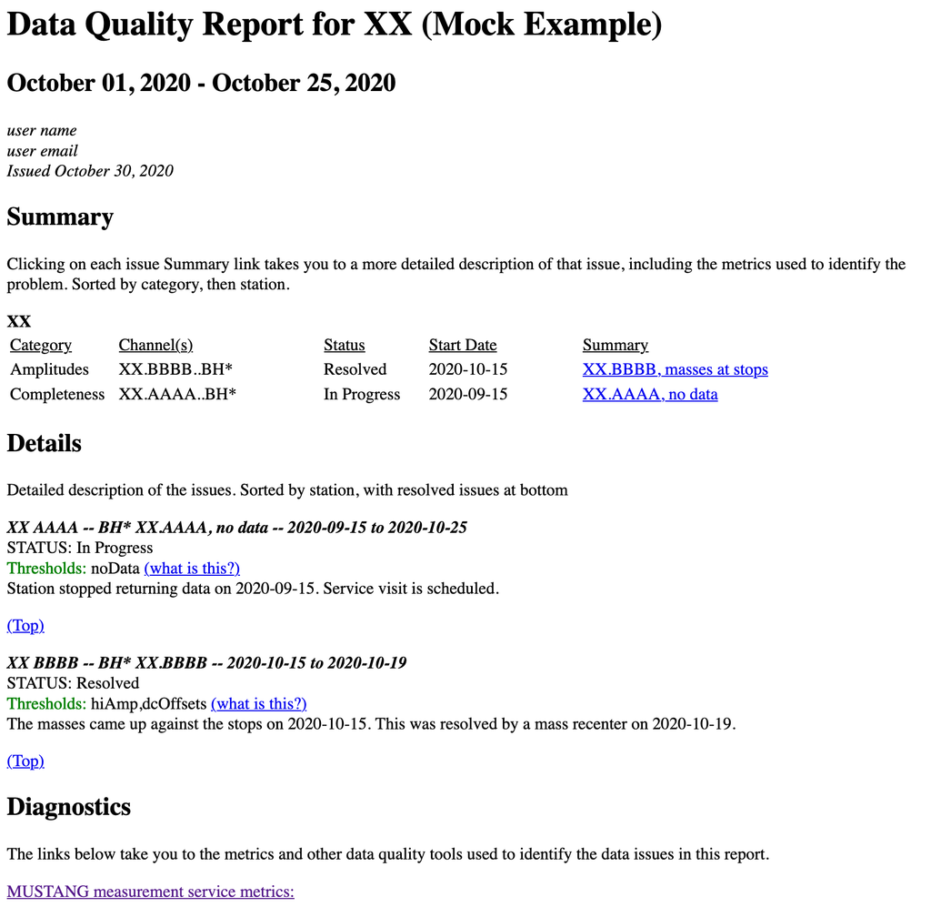

If there are images included in the report, which is suggested, then all image files and the final report will be moved into a separate directory and zipped for easy transferral.

The Report contains four general sections:

- *Header Information*: At the very top of the report is information about the report period, the date it was issued, and who created it.
- *Summary*: This is a very quick overview of all of the tickets listed in more detail below. All of these fields come directly from the Ticket File (see above) which is derived from the tickets themselves.
  - Category - General category of the issue
  - Channel(s) - Affected target(s)
  - Start Date - Date the issue began, if supplied
  - Summary - This is the “Subject” field from the ticket - a very brief description of the issue. Click on the Summary to take you directly to the Detailed Description for that particular issue.
- *Detailed Description*: Where the issue is fully described, including links and images if included.
  - Target - Affected target(s)
  - Diagnostics - MUSTANG metrics used to find the issue (metrics used in the thresholds below)
  - Thresholds - Thresholds used to find the issue
  - Description - A thorough description of the problem to allow others to understand the scope of the problem, ideally guiding decision making and field operations for plans on improvement
  - Images - Any linked images will show here, along with potential captions
- *Diagnostic Information*: At the bottom of the report are a number of links that may be useful for QA or for better understanding the metrics. There are also definitions of the thresholds used so that there is a record
  - MUSTANG Metrics - a list of MUSTANG metrics, as well as a link to the service page
  - Links - links to various MUSTANG web services, as well as other EarthScope sites that may be helpful in diagnosing issues
    - *MUSTANG noise-psd service*: the service interface for our PSD service. This page lists information about how to use the service, and the URL builder (near top) can be used to create queries related to your network.
    - *MUSTANG noise-pdf service*: the service interface for our PDF service. This page lists information about how to use the service, and the URL builder (near top) can be used to create queries related to your network.
    - *MUSTANG noise-mode-timeseries service*: the service interface for our noise mode timeseries service. This service plots the values of various frequencies (the mode value for each frequency for the day) over time so that you can see trends in the noise levels. This page lists information about how to use the service, and the URL builder (near top) can be used to create queries related to your network.
    - *Metadata Aggregator*: MDA displays all of the metadata that we have in our holdings, as well as the metadata from other federated data centers (the source of the metadata is listed under the “Data Center” field).
    - *BUD stats*: this is currently the only public-facing interface where you can get information about whether you have data in Purgatory, meaning that the data is streaming into EarthScope but cannot be archived because we do not have metadata for it. The page contains a lot more information than just that, though. This page describes what we have in the BUD (Buffer of Uniform Data, the data streaming into EarthScope in realtime). For each day of data that we have in the BUD, there is a link. That link will have information about all of the networks that have data in the BUD for that day. If your network has a blue M next to it, then there is metadata for all of the data for that day. But if it has a grey M, then there are some channels coming into EarthScope that do not have metadata. Click on the network to dive deeper, where you now get a list of stations. Again, a blue M means that the station has complete metadata, a grey one means there is some missing. Click on the station and it will break down by channel. A blue M means that we have metadata, but channels without the icon next to it are missing metadata. For those stations, the “Purgatory” column should be marked as “True” - meaning that it cannot be archived. These channels should either have metadata provided, the data streams should be shut off, or there could be an error in the channel name in the data or the metadata so that they do not match. By correcting the situation, we can ensure that all data that should be getting archived at EarthScope will be archived.
  - Thresholds - a list of the definitions of all thresholds. Will print the broadband thresholds if `broadband` is included in the instruments list in the preference file; will print the short period thresholds if `short period` is included in the instruments list.

##### Transient Files

Back to Table of Contents

On top of the files described above, there are a few truly transient files that are generated and destroyed in the process of the final report. If the program is stopped or crashes in the middle of generating the final report, one or more of these files may exist and ought to be removed. Without going into detail, these include:

- HTML Summary file - `summaryFile = outfile + '.summary'`, where `outfile` is from the preference file
- HTML Detail file - `detailFile = outfile + '.detail'`, where `outfile` is from the preference file

In addition, there is a file that is created and destroyed when Finding Issues. If this file isn’t properly generated, or if it is somehow removed during the Find Issues process, then it will pop up with a warning.

- Failed Metrics file - `failedMetrics.txt` keeps track of any and all metrics that produced an error when QuARG attempted to retrieve them. It is used to produce a popup that lists the failures so that the user is aware of the issue and can either run Find Issues again, or at minimum be aware that some thresholds may be incomplete because the metrics were not retrieved. If a warning is produced that the file failedMetrics.txt is missing, this could indicate that some process in QuARG crashed, and you may want to look at the comman line for more information about the problem.

# Appendix

### Appendix A - list of default thresholds

Back to Table of Contents

*ampSat*  
broadband - amplifier_saturation > 0  
short period - amplifier_saturation > 0  
*avgGaps*  
broadband - average :: num_gaps >= 2  
short period - average :: num_gaps >= 2  
strongmotion - average :: num_gaps >= 2  
*avgSpikes*  
broadband - average :: num_spikes > 100  
*badResp*  
broadband - pct_above_nhnm > 90 && dead_channel_lin > 2  
short period - pct_above_nhnm > 90  
*badResp2*  
broadband - dead_channel_lin > 2 && pct_above_nhnm < -90.0  
short period - pct_above_nhnm < 90  
*clip*  
broadband - digitizer_clipping > 0  
short period - digitizer_clipping > 0  
*dcOffsets*  
broadband - dc_offset > 10  
short period - dc_offset > 10  
*dead*  
broadband - dead_channel_gsn = 1.0  
*filtChg*  
broadband - digital_filter_charging > 2  
short period - digital_filter_charging > 2  
*flat*  
broadband - sample_unique < 200  
short period - sample_unique < 50  
*gainRatio*  
broadband - transfer_function::ms_coherence >= 0.999 && transfer_function::gain_ratio <= 0.95  
*gainRatioB*  
broadband - transfer_function::ms_coherence > 0.999 && transfer_function::gain_ratio >= 1.05  
*gapsRatioGt12*  
broadband - num_gaps / percent_availability >= 0.12  
short period - num_gaps / percent_availability >= 0.12  
strongmotion - num_gaps / percent_availability >= 0.12  
*glitch*  
broadband - glitches > 0  
short period - glitches > 0  
*hiAmp*  
broadband - pct_above_nhnm > 30 && sample_rms > 50000  
short period - pct_above_nhnm > 40  
*horDip*  
broadband - Dip[H] != 0.0  
short period - Dip[H] != 0.0  
strongmotion - Dip[H] != 0.0  
*lowAmp*  
broadband - dead_channel_lin >= 3.5 && pct_below_nlnm > 20  
short period - pct_below_nlnm > 0  
*lowRms*  
broadband - sample_rms < 25  
short period - sample_rms < 10  
*lowScale*  
broadband - Scale <= 0  
short period - Scale <= 0  
*medianUnique*  
broadband - median :: sample_unique = 1.0  
*nSpikes*  
broadband - num_spikes >= 500  
*noData*  
broadband - percent_availability = 0  
short period - percent_availability = 0  
strongmotion - percent_availability = 0  
*noTime*  
broadband - clock_locked = 0  
short period - clock_locked = 0  
*noise1*  
broadband - dead_channel_lin < 2.25 && pct_above_nhnm > 20  
*noise2*  
broadband - dead_channel_lin < 2 && pct_below_nlnm <= 20 && num_gaps < 10  
*nonCoher*  
broadband - transfer_function::ms_coherence < 0.99  
*nonMSUnits*  
broadband - ScaleUnits != M/S && ScaleUnits != m/s  
short period - ScaleUnits != M/S && ScaleUnits != m/s  
*padding*  
broadband - missing_padded_data > 0  
short period - missing_padded_data > 0  
*pegged*  
broadband - sample_rms < 1000 && abs(sample_mean) > 6000000.0  
*polarity*  
broadband - polarity_check <= -0.5  
*poorTQual*  
broadband - timing_quality >= 0 && timing_quality < 60  
short period - timing_quality >= 0 && timing_quality < 60  
*rmsRatio*  
broadband - sample_rms[V] / sample_rms[H:avg] > 10.0  
*rmsRatio_horiz*  
broadband - sample_rms[H:vs] / sample_rms[H:vs] > 10.0  
*spikes*  
broadband - spikes > 0  
short period - spikes > 0  
*suspectTime*  
broadband - suspect_time_tag > 1  
short period - suspect_time_tag > 1  
*tSync*  
broadband - telemetry_sync_error > 0  
short period - telemetry_sync_error > 0  
*xTalk*  
broadband - abs(cross_talk) >= 0.9  
*zDip*  
broadband - Dip[V] > -90.0  
short period - Dip[V] > -90.0  
strongmotion - Dip[V] > -90.0  
*zeroZ*  
broadband - Elevation = 0 && Depth = 0  
short period - Elevation = 0 && Depth = 0

Back to Table of Contents